# Trabajo Final Integrador Ciencia de Datos

## 10.2 9.2 Contribución a componentes principales

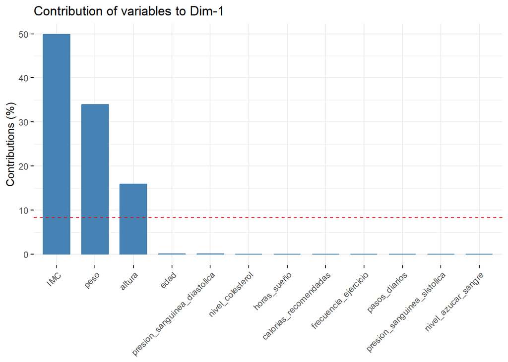

```r
fviz_contrib(pca_resultado, choice = "var", axes = 1, top = 15)
```

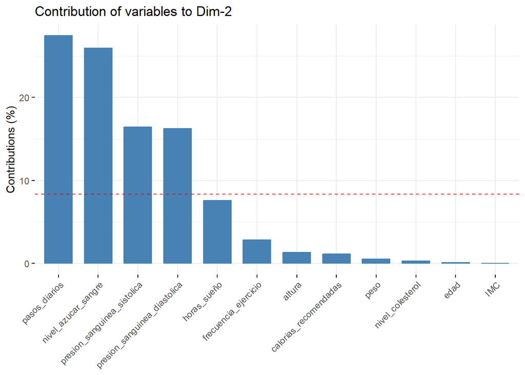

```r
fviz_contrib(pca_resultado, choice = "var", axes = 2, top = 15)
```

Las dos primeras dimensiones del PCA presentan interpretaciones distintas y complementarias. La Dim-1 refleja diferencias antropométricas entre individuos, fuertemente influenciada por el IMC, el peso y la altura. Por otro lado, la Dim-2 agrupa a los pacientes según su nivel de actividad física y parámetros clínicos relacionados con el metabolismo, como pasos diarios, presión arterial y glucemia. Esta diferenciación dimensional resulta útil para segmentar perfiles de pacientes antes de aplicar técnicas de clustering.

## 10.3 9.3 Proyección de individuos

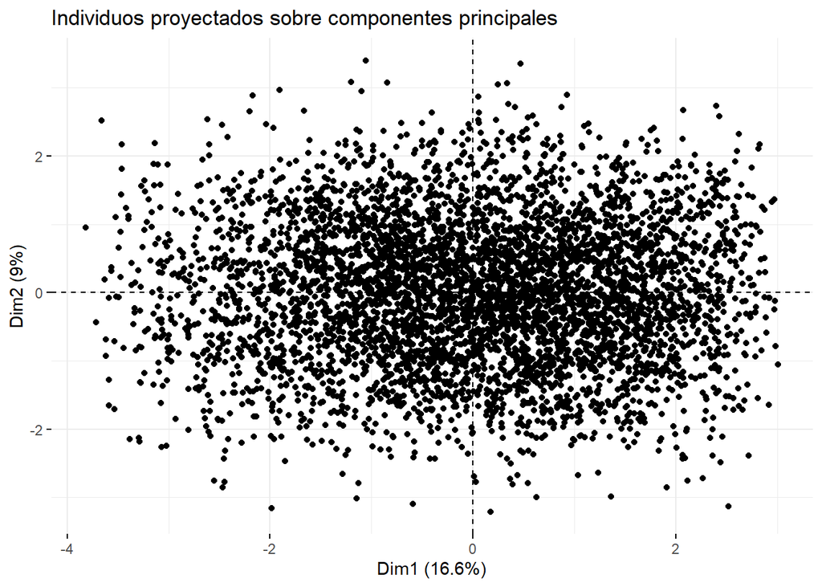

```r
fviz_pca_ind(pca_resultado,
             geom.ind = "point",
             palette = "Set2",
             title = "Individuos proyectados sobre componentes principales")
```

La proyección de los individuos sobre las dos primeras componentes principales muestra una distribución densa y dispersa sin agrupamientos visuales definidos. Esto indica que no existen patrones evidentes en el espacio reducido, por lo #que será necesario aplicar técnicas de clustering para detectar segmentaciones más estructuradas.

## 10.4 9.4 Selección de primeras 10 componentes

```r
pca_data <- as.data.frame(pca_resultado$x[, 1:10])
```

## 10.5 9.5 Determinación del número óptimo de clusters

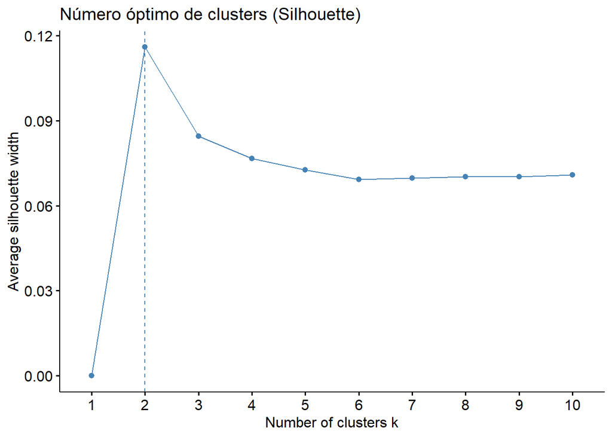

```r
fviz_nbclust(pca_data, function(x, k) kmeans(x, centers = k, iter.max = 100,
                                             nstart = 25),
             method = "silhouette") +
  labs(title = "Número óptimo de clusters (Silhouette)")
```

El coeficiente de silueta alcanza su valor máximo cuando el número de clusters es k = 2, lo que indica que esta es la cantidad óptima para una segmentación inicial. A partir de k = 3, la calidad del agrupamiento disminuye progresivamente.